# Fundamentals of Data Visualization: Figures Notebook

Author

Erik Westlund

Published

October 7, 2026

This notebook makes every figure in the talk *Fundamentals of Data Visualization* and saves each one as a PNG in `images/fundamentals/`, where the slides read them from.

The data come from the course repository erikwestlund/data-visualization-2026. They are public data simplified for teaching (NHANES, PRAMS, CDC FluVaxView, and Leinhardt and Wasserman’s infant mortality data). They are fine for illustrating figures but should not be used for research.

```r
library(framework)
scaffold()

library(patchwork)
```

```r
image_dir <- "images/fundamentals"
dir.create(image_dir, recursive = TRUE, showWarnings = FALSE)

# Save a figure for the slides, at the size the slides expect
save_figure <- function(plot, name, width = 10, height = 5.6) {
  ggsave(file.path(image_dir, paste0(name, ".png")), plot,
         width = width, height = height, dpi = 200, device = ragg::agg_png)
  plot
}
```

```r
nhanes <- data_read("data/nhanes_2021_2023_analysis.csv")
prams <- data_read("data/prams_2011_selected.csv")
countries <- data_read("data/infant_mortality_countries.csv")
flu <- data_read("data/flu_vaccination_age_time_clean.csv")
```

# Principles

These figures use small made-up numbers so each principle is easy to see.

## Principle 1: Use a common scale

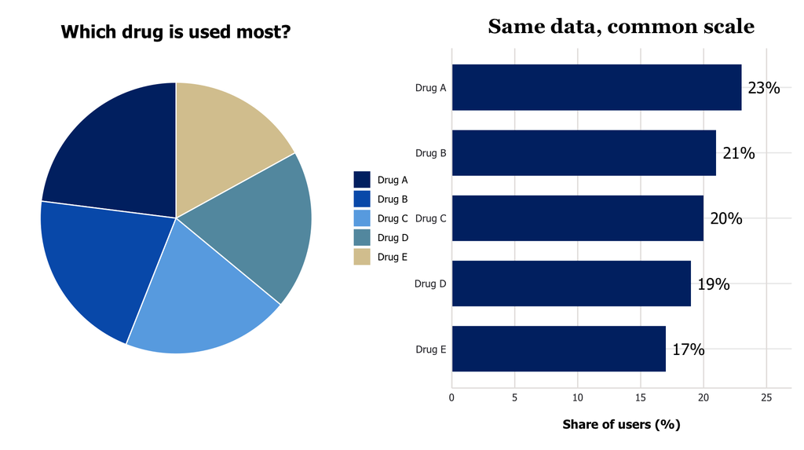

```r
shares <- tibble(
  drug = c("Drug A", "Drug B", "Drug C", "Drug D", "Drug E"),
  pct = c(23, 21, 20, 19, 17)
)

pie <- ggplot(shares, aes(x = "", y = pct, fill = drug)) +
  geom_col(width = 1, color = "white") +
  coord_polar(theta = "y") +
  scale_fill_manual(values = unname(unlist(jhu_colors[c(
    "HopkinsBlue", "Blue", "BlueLight", "Teal", "Tan"
  )]))) +
  labs(title = "Which drug is used most?", fill = NULL) +
  theme_void(base_family = "Tahoma") +
  theme(plot.title = element_text(hjust = 0.5, face = "bold", size = 16))

bars <- ggplot(shares, aes(x = pct, y = reorder(drug, pct))) +
  geom_col(fill = jhu_colors$HopkinsBlue, width = 0.7) +
  geom_text(aes(label = paste0(pct, "%")), hjust = -0.2, size = 5) +
  scale_x_continuous(limits = c(0, 27), expand = c(0, 0)) +
  labs(title = "Same data, common scale", x = "Share of users (%)", y = NULL) +
  theme_jhu()

save_figure(pie + bars, "principle-common-scale")
```

## Principle 2: Pick the right chart for your data

Bars encode values as length, so they start at zero. A truncated axis makes small differences look large. Group means are better shown as dots. A dot encodes its value by position, so the axis can zoom in on the range where the means differ, and intervals fit naturally.

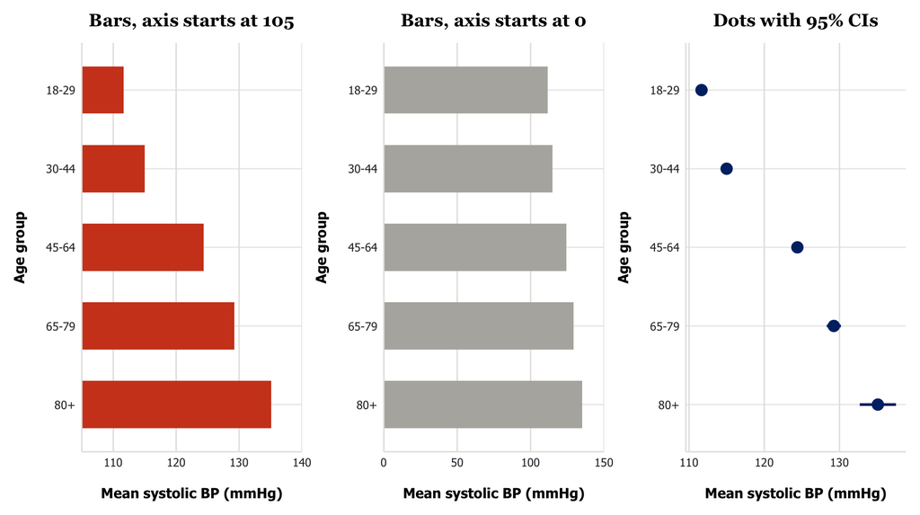

```r
bp_means <- nhanes |>
  filter(age_years >= 18, !is.na(systolic_mean)) |>
  group_by(age_group) |>
  summarize(
    n = n(),
    mean = mean(systolic_mean),
    se = sd(systolic_mean) / sqrt(n),
    lower = mean - 1.96 * se,
    upper = mean + 1.96 * se
  ) |>
  # Youngest group at the top
  mutate(age_group = factor(age_group, levels = rev(sort(unique(age_group)))))

mean_plot <- function(title) {
  ggplot(bp_means, aes(x = mean, y = age_group)) +
    labs(title = title, x = "Mean systolic BP (mmHg)", y = "Age group") +
    theme_jhu() +
    theme(plot.title = element_text(size = 14))
}

truncated_bars <- mean_plot("Bars, axis starts at 105") +
  geom_col(fill = jhu_colors$Red, width = 0.6) +
  coord_cartesian(xlim = c(105, 140)) +
  scale_x_continuous(expand = c(0, 0))

zero_bars <- mean_plot("Bars, axis starts at 0") +
  geom_col(fill = jhu_colors$Gray2, width = 0.6) +
  scale_x_continuous(limits = c(0, 150), expand = c(0, 0))

mean_dots <- mean_plot("Dots with 95% CIs") +
  geom_pointrange(aes(xmin = lower, xmax = upper), color = jhu_colors$HopkinsBlue,
                  size = 0.8, linewidth = 1)

save_figure(truncated_bars + zero_bars + mean_dots, "principle-right-chart", width = 12)
```

## Principle 3: Order categories meaningfully

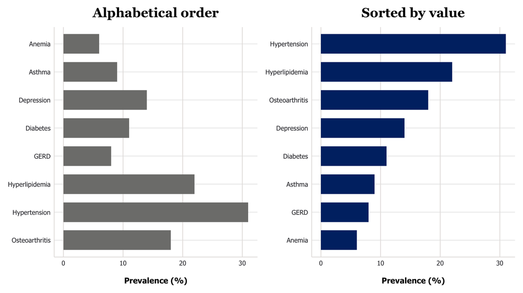

```r
conditions <- tibble(
  condition = c("Anemia", "Asthma", "Depression", "Diabetes", "GERD",
                "Hyperlipidemia", "Hypertension", "Osteoarthritis"),
  pct = c(6, 9, 14, 11, 8, 22, 31, 18)
)

alphabetical <- ggplot(conditions, aes(x = pct, y = factor(condition, levels = rev(sort(condition))))) +
  geom_col(fill = jhu_colors$Gray3, width = 0.7) +
  labs(title = "Alphabetical order", x = "Prevalence (%)", y = NULL) +
  theme_jhu()

sorted <- ggplot(conditions, aes(x = pct, y = reorder(condition, pct))) +
  geom_col(fill = jhu_colors$HopkinsBlue, width = 0.7) +
  labs(title = "Sorted by value", x = "Prevalence (%)", y = NULL) +
  theme_jhu()

save_figure(alphabetical + sorted, "principle-order")
```

## Principle 4: Label directly

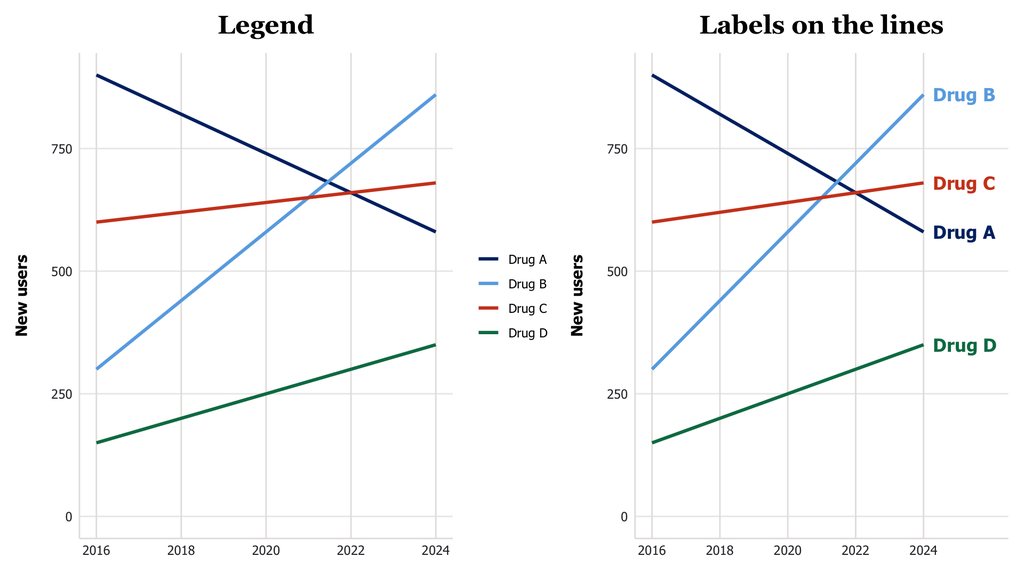

```r
drug_colors_4 <- c(
  "Drug A" = jhu_colors$HopkinsBlue, "Drug B" = jhu_colors$BlueLight,
  "Drug C" = jhu_colors$Red, "Drug D" = jhu_colors$Green
)

uptake <- expand_grid(drug = names(drug_colors_4), year = 2016:2024) |>
  mutate(users = case_when(
    drug == "Drug A" ~ 900 - 40 * (year - 2016),
    drug == "Drug B" ~ 300 + 70 * (year - 2016),
    drug == "Drug C" ~ 600 + 10 * (year - 2016),
    drug == "Drug D" ~ 150 + 25 * (year - 2016)
  ))

with_legend <- ggplot(uptake, aes(x = year, y = users, color = drug)) +
  geom_line(linewidth = 1.1) +
  scale_color_manual(values = drug_colors_4) +
  expand_limits(y = 0) +
  labs(title = "Legend", x = NULL, y = "New users", color = NULL) +
  theme_jhu() +
  theme(legend.position = "right")

with_labels <- ggplot(uptake, aes(x = year, y = users, color = drug)) +
  geom_line(linewidth = 1.1) +
  geom_text(data = filter(uptake, year == max(year)),
            aes(label = drug), hjust = -0.15, size = 4.5, fontface = "bold") +
  scale_color_manual(values = drug_colors_4, guide = "none") +
  scale_x_continuous(limits = c(2016, 2026), breaks = seq(2016, 2024, 2)) +
  expand_limits(y = 0) +
  labs(title = "Labels on the lines", x = NULL, y = "New users") +
  theme_jhu()

save_figure(with_legend + with_labels, "principle-direct-labels")
```

## Principle 5: Use small multiples

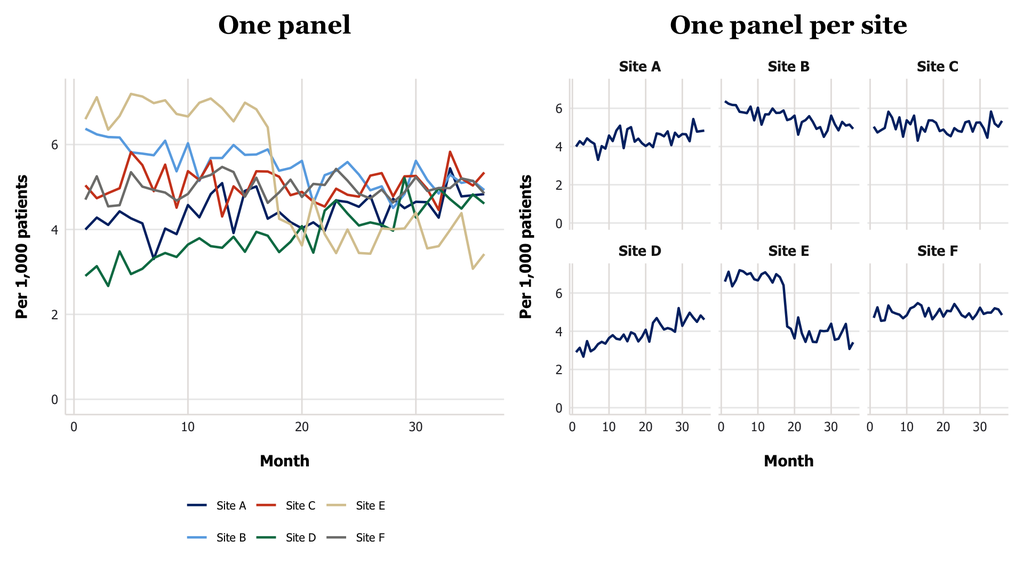

```r
set.seed(20261007)
sites <- paste("Site", LETTERS[1:6])
monthly <- expand_grid(site = sites, month = 1:36) |>
  mutate(
    base = c(4, 6, 5, 3, 7, 5)[match(site, sites)],
    trend = c(0.02, -0.03, 0, 0.05, -0.01, 0)[match(site, sites)],
    jump = if_else(site == "Site E" & month >= 18, -3, 0),
    rate = base + trend * month + jump + rnorm(n(), 0, 0.35)
  )

site_colors <- setNames(
  unname(unlist(jhu_colors[c("HopkinsBlue", "BlueLight", "Red", "Green", "Tan", "Gray3")])),
  sites
)

tangled <- ggplot(monthly, aes(x = month, y = rate, color = site)) +
  geom_line(linewidth = 0.8) +
  scale_color_manual(values = site_colors) +
  expand_limits(y = 0) +
  labs(title = "One panel", x = "Month", y = "Per 1,000 patients", color = NULL) +
  theme_jhu() +
  theme(legend.position = "bottom", legend.text = element_text(size = 8))

multiples <- ggplot(monthly, aes(x = month, y = rate)) +
  geom_line(color = jhu_colors$HopkinsBlue, linewidth = 0.8) +
  facet_wrap(~site, ncol = 3) +
  expand_limits(y = 0) +
  labs(title = "One panel per site", x = "Month", y = "Per 1,000 patients") +
  theme_jhu() +
  theme(strip.text = element_text(size = 10, face = "bold"))

save_figure(tangled + multiples, "principle-small-multiples")
```

Kostecki-Dillon, Monette, and Wong’s migraine diaries: 133 people recorded whether they had a headache each day. Day 0 is the start of treatment. As in the course module, days after day 50 are dropped.

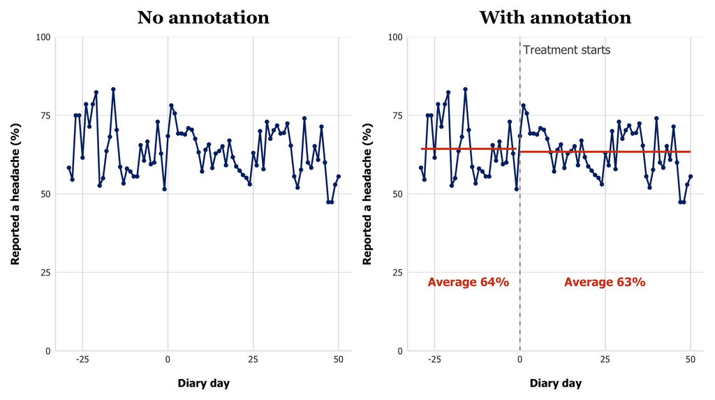

```r
migraine <- data_read("data/migraine_headache_diary.csv")

headache_days <- migraine |>
  filter(!is.na(day), day <= 50, !is.na(headache_reported)) |>
  group_by(day) |>
  summarize(n = n(), pct = mean(headache_reported) * 100) |>
  mutate(treated = day >= 0)

period_means <- headache_days |>
  group_by(treated) |>
  summarize(start = min(day), end = max(day), mean = mean(pct))

headache_plot <- function(title) {
  ggplot(headache_days, aes(x = day, y = pct)) +
    geom_line(color = jhu_colors$HopkinsBlue, linewidth = 0.8) +
    geom_point(color = jhu_colors$HopkinsBlue, size = 1.4) +
    scale_y_continuous(limits = c(0, 100), expand = c(0, 0)) +
    labs(title = title, x = "Diary day", y = "Reported a headache (%)") +
    theme_jhu()
}

plain <- headache_plot("No annotation")

annotated <- headache_plot("With annotation") +
  geom_vline(xintercept = 0, color = jhu_colors$Gray3, linetype = "dashed") +
  annotate("text", x = 1, y = 96, label = "Treatment starts", hjust = 0,
           size = 4.2, color = jhu_colors$Gray4) +
  geom_segment(data = period_means,
               aes(x = start, xend = end, y = mean, yend = mean),
               inherit.aes = FALSE, color = jhu_colors$Red, linewidth = 1) +
  geom_text(data = period_means,
            aes(x = (start + end) / 2, y = 22,
                label = paste0("Average ", round(mean), "%")),
            inherit.aes = FALSE, color = jhu_colors$Red, fontface = "bold", size = 4.2)

save_figure(plain + annotated, "principle-annotation")
```

## Principle 6: Use color to highlight

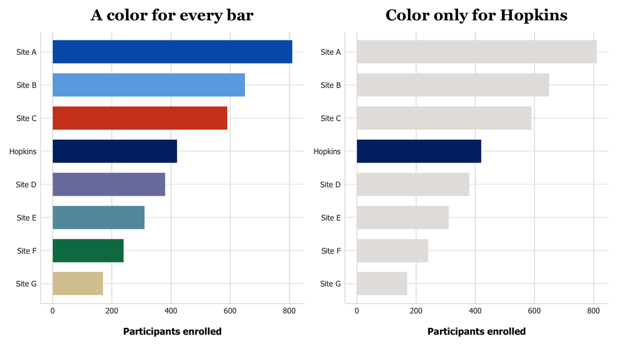

```r
enrollment <- tibble(
  site = c("Hopkins", paste("Site", LETTERS[1:7])),
  enrolled = c(420, 810, 650, 590, 380, 310, 240, 170)
)

rainbow <- ggplot(enrollment, aes(x = enrolled, y = reorder(site, enrolled), fill = site)) +
  geom_col(width = 0.7) +
  scale_fill_manual(values = unname(unlist(jhu_colors[c(
    "HopkinsBlue", "Blue", "BlueLight", "Red", "LightPurple", "Teal", "Green", "Tan"
  )])), guide = "none") +
  labs(title = "A color for every bar", x = "Participants enrolled", y = NULL) +
  theme_jhu()

highlight <- ggplot(enrollment, aes(x = enrolled, y = reorder(site, enrolled),
                                    fill = site == "Hopkins")) +
  geom_col(width = 0.7) +
  scale_fill_manual(values = c(`TRUE` = jhu_colors$HopkinsBlue, `FALSE` = jhu_colors$Gray1),
                    guide = "none") +
  labs(title = "Color only for Hopkins", x = "Participants enrolled", y = NULL) +
  theme_jhu()

save_figure(rainbow + highlight, "principle-highlight")
```

## Principle 7: State the finding in the title

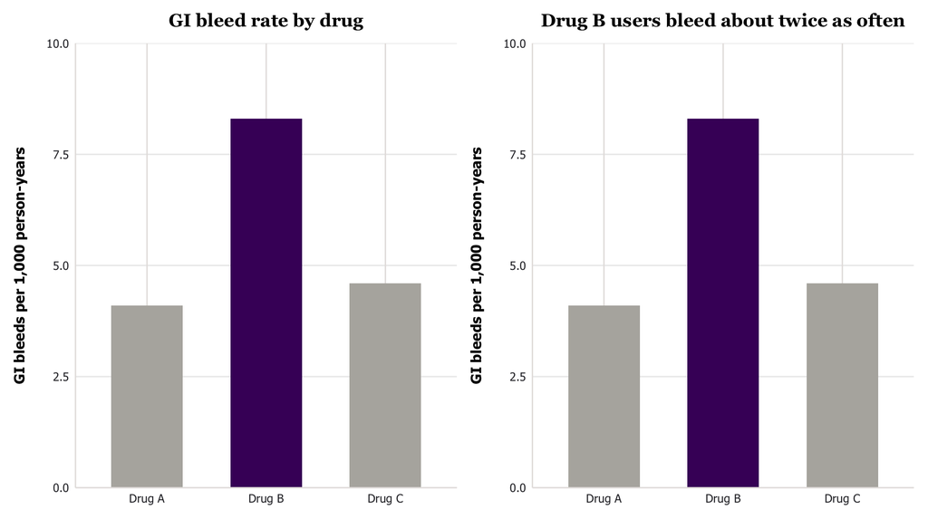

```r
bleeds <- tibble(drug = c("Drug A", "Drug B", "Drug C"), rate = c(4.1, 8.3, 4.6))

bleed_bars <- function(title) {
  ggplot(bleeds, aes(x = drug, y = rate)) +
    geom_col(fill = if_else(bleeds$drug == "Drug B", jhu_colors$Purple, jhu_colors$Gray2),
             width = 0.6) +
    scale_y_continuous(limits = c(0, 10), expand = c(0, 0)) +
    labs(title = title, x = NULL, y = "GI bleeds per 1,000 person-years") +
    theme_jhu() +
    theme(plot.title = element_text(size = 14))
}

save_figure(bleed_bars("GI bleed rate by drug") + bleed_bars("Drug B users bleed about twice as often"),
            "principle-title")
```

# Tips and tricks

## Use a reusable theme

The same plot with the ggplot2 default theme and with `theme_jhu()`, which lives in `functions/theme_jhu.R`. Only the styling changes.

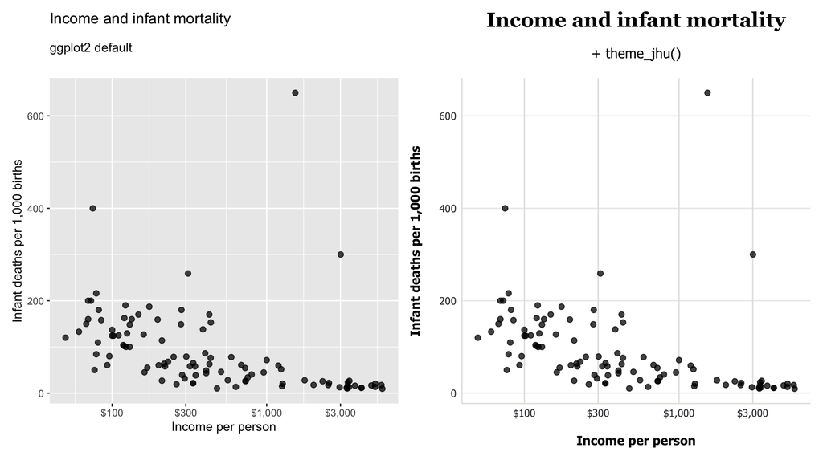

```r
theme_example <- countries |>
  filter(!is.na(infant_mortality_per_1000), !is.na(income_usd_per_capita)) |>
  ggplot(aes(x = income_usd_per_capita, y = infant_mortality_per_1000)) +
  geom_point(alpha = 0.75, size = 2) +
  scale_x_log10(labels = scales::label_dollar(accuracy = 1)) +
  labs(
    title = "Income and infant mortality",
    x = "Income per person",
    y = "Infant deaths per 1,000 births"
  )

save_figure(
  (theme_example + theme_gray() + labs(subtitle = "ggplot2 default")) +
    (theme_example + theme_jhu() + labs(subtitle = "+ theme_jhu()")),
  "tip-theme"
)
```

# Workhorses

Workhorses use `theme_minimal()` defaults and short labels. They are the figures you make while exploring.

```r
# Adults with a blood pressure reading
adult_bp <- nhanes |>
  filter(age_years >= 18, !is.na(systolic_mean))

# Everyone with at least one dietary recall
diet <- nhanes |>
  filter(!is.na(mean_daily_energy_kcal), mean_daily_energy_kcal > 0)
```

## Histogram

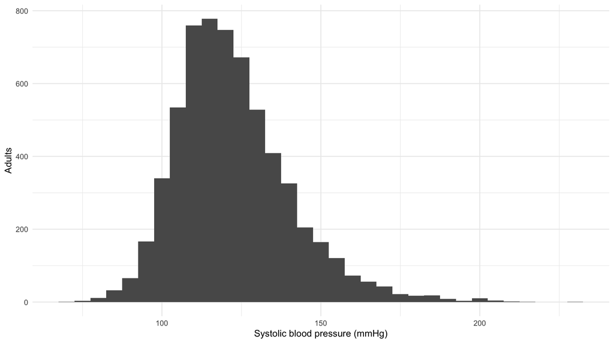

```r
histogram <- ggplot(adult_bp, aes(x = systolic_mean)) +
  geom_histogram(binwidth = 5) +
  labs(x = "Systolic blood pressure (mmHg)", y = "Adults")

save_figure(histogram, "histogram")
```

## Bin width

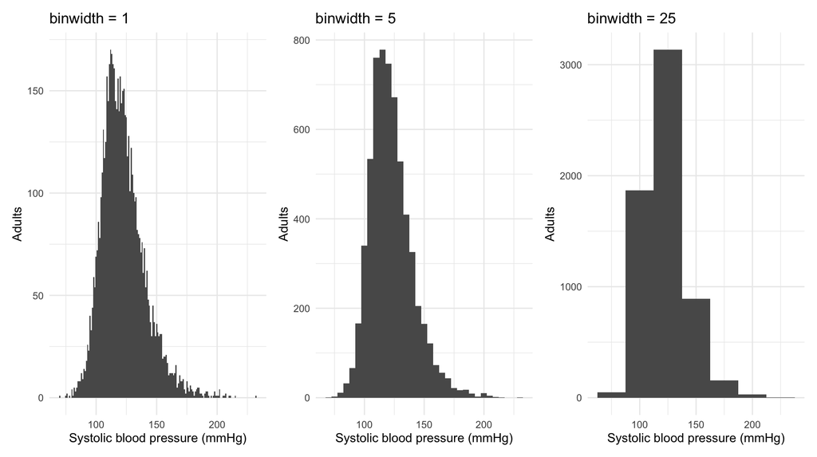

```r
bin_plot <- function(binwidth) {
  ggplot(adult_bp, aes(x = systolic_mean)) +
    geom_histogram(binwidth = binwidth) +
    labs(title = paste("binwidth =", binwidth),
         x = "Systolic blood pressure (mmHg)", y = "Adults")
}

save_figure(bin_plot(1) + bin_plot(5) + bin_plot(25), "histogram-binwidth", height = 4.2)
```

## Box plot

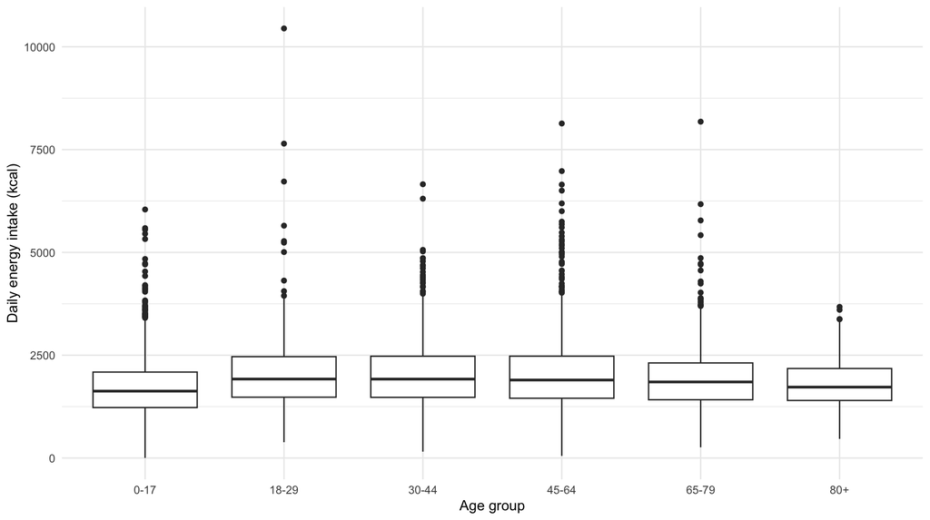

```r
boxplot <- ggplot(diet, aes(x = age_group, y = mean_daily_energy_kcal)) +
  geom_boxplot() +
  labs(x = "Age group", y = "Daily energy intake (kcal)")

save_figure(boxplot, "boxplot")
```

## Box plot with the data

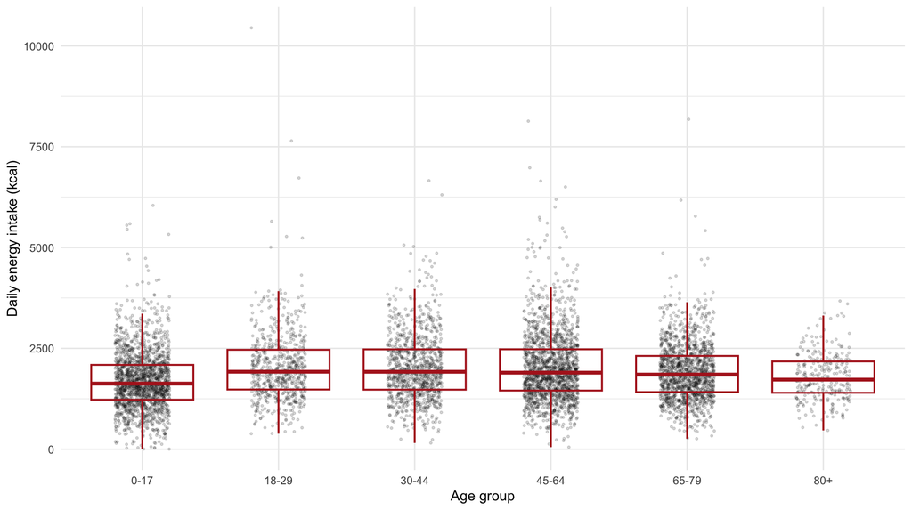

```r
boxplot_points <- ggplot(diet, aes(x = age_group, y = mean_daily_energy_kcal)) +
  geom_jitter(width = 0.2, alpha = 0.15, size = 0.6) +
  geom_boxplot(outlier.shape = NA, fill = NA, color = "firebrick", linewidth = 0.7) +
  labs(x = "Age group", y = "Daily energy intake (kcal)")

save_figure(boxplot_points, "boxplot-points")
```

## Violin plot

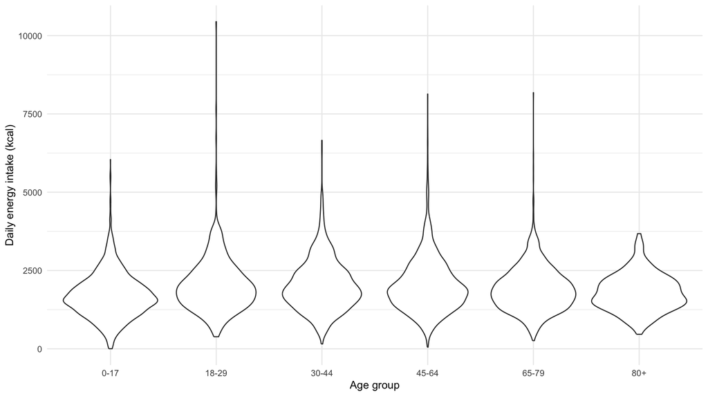

```r
violin <- ggplot(diet, aes(x = age_group, y = mean_daily_energy_kcal)) +
  geom_violin() +
  labs(x = "Age group", y = "Daily energy intake (kcal)")

save_figure(violin, "violin")
```

## Violin plot with a box plot

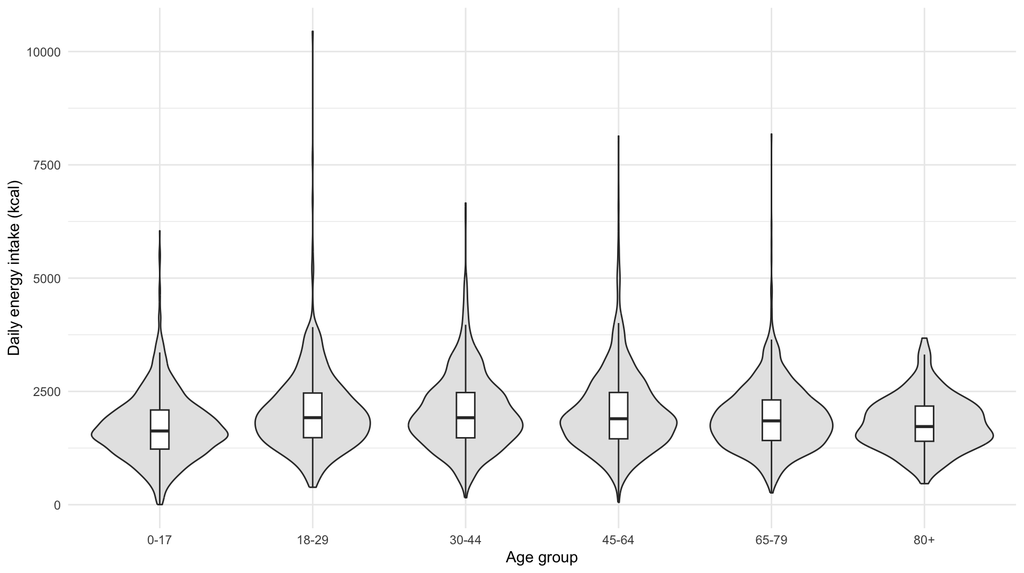

```r
violin_boxplot <- ggplot(diet, aes(x = age_group, y = mean_daily_energy_kcal)) +
  geom_violin(fill = "gray90") +
  geom_boxplot(width = 0.12, outlier.shape = NA) +
  labs(x = "Age group", y = "Daily energy intake (kcal)")

save_figure(violin_boxplot, "violin-boxplot")
```

# Show ponies

Each show pony starts from a workhorse. Same data, same geoms, then polish.

## Blood pressure by age

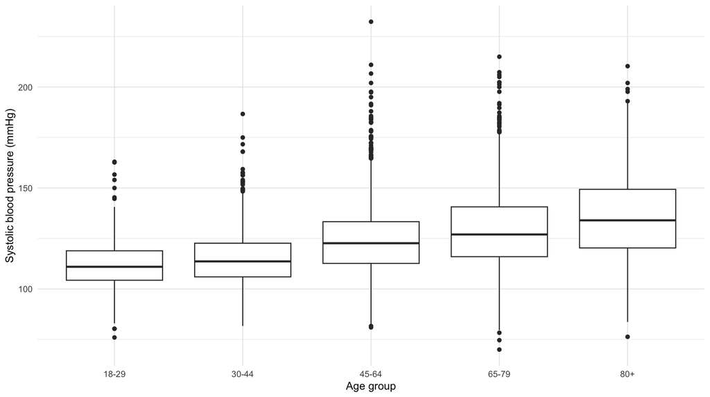

```r
bp_workhorse <- ggplot(adult_bp, aes(x = age_group, y = systolic_mean)) +
  geom_boxplot() +
  labs(x = "Age group", y = "Systolic blood pressure (mmHg)")

save_figure(bp_workhorse, "bp-workhorse")
```

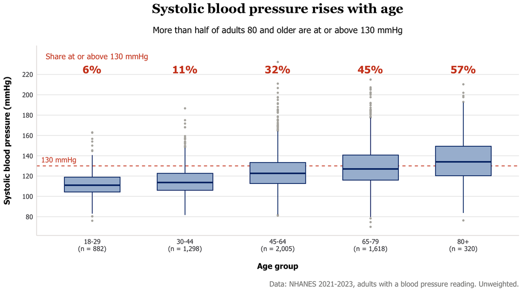

```r
# Share of each age group at or above 130 mmHg, the stage 1 hypertension threshold
bp_summary <- adult_bp |>
  group_by(age_group) |>
  summarize(n = n(), pct_130 = mean(systolic_mean >= 130)) |>
  mutate(
    axis_label = paste0(age_group, "\n(n = ", scales::comma(n), ")"),
    pct_label = scales::percent(pct_130, accuracy = 1)
  )

bp_show_pony <- ggplot(adult_bp, aes(x = age_group, y = systolic_mean)) +
  geom_hline(yintercept = 130, color = jhu_colors$Red, linetype = "dashed") +
  geom_boxplot(fill = jhu_colors$PaleBlue, color = jhu_colors$HopkinsBlue,
               outlier.color = jhu_colors$Gray2, outlier.size = 0.8, width = 0.6) +
  geom_text(data = bp_summary, aes(y = 225, label = pct_label),
            color = jhu_colors$Red, fontface = "bold", size = 5) +
  annotate("text", x = 0.5, y = 238, label = "Share at or above 130 mmHg", hjust = 0,
           color = jhu_colors$Red, size = 3.8) +
  annotate("text", x = 0.45, y = 131, label = "130 mmHg", hjust = 0, vjust = -0.5,
           color = jhu_colors$Red, size = 3.5) +
  scale_x_discrete(labels = bp_summary$axis_label) +
  scale_y_continuous(limits = c(70, 240), breaks = seq(80, 220, 20)) +
  labs(
    title = "Systolic blood pressure rises with age",
    subtitle = "More than half of adults 80 and older are at or above 130 mmHg",
    x = "Age group", y = "Systolic blood pressure (mmHg)",
    caption = "Data: NHANES 2021-2023, adults with a blood pressure reading. Unweighted."
  ) +
  theme_jhu() +
  theme(panel.grid.major.x = element_blank())

save_figure(bp_show_pony, "bp-show-pony")
```

## Postpartum depression and anxiety

PRAMS state estimates are percentages for all respondents in the state.

```r
mental_health <- prams |>
  filter(
    subgroup_cat == "None",
    !is.na(depression_within_3_months_birth),
    !is.na(anxiety_within_3_months_birth)
  ) |>
  transmute(
    location,
    depression = depression_within_3_months_birth,
    anxiety = anxiety_within_3_months_birth,
    difference = anxiety - depression
  )

mental_health_long <- mental_health |>
  pivot_longer(c(depression, anxiety), names_to = "measure", values_to = "estimate") |>
  mutate(measure = str_to_title(measure))
```

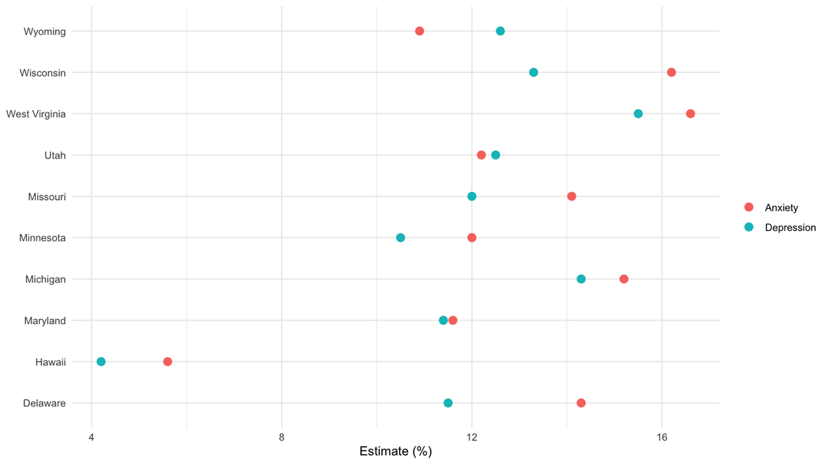

```r
prams_workhorse <- ggplot(mental_health_long, aes(x = estimate, y = location, color = measure)) +
  geom_point(size = 3) +
  labs(x = "Estimate (%)", y = NULL, color = NULL)

save_figure(prams_workhorse, "prams-workhorse")
```

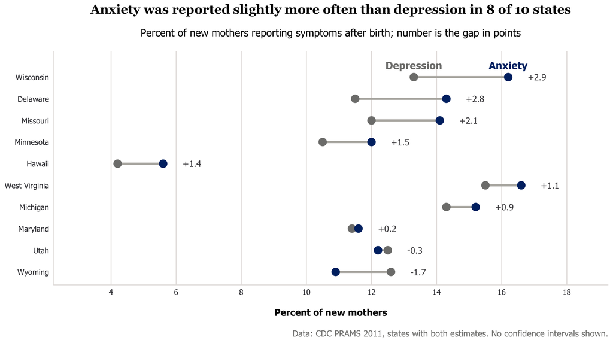

```r
measure_colors <- c(Depression = jhu_colors$Gray3, Anxiety = jhu_colors$HopkinsBlue)

n_higher <- sum(mental_health$difference > 0)

# Sort states by the gap, largest at the top
state_order <- mental_health |>
  arrange(difference) |>
  pull(location)

prams_sorted <- mental_health |>
  mutate(location = factor(location, levels = state_order))

prams_points <- mental_health_long |>
  mutate(location = factor(location, levels = state_order))

top_row <- prams_points |>
  filter(location == last(state_order))

prams_show_pony <- ggplot(prams_sorted, aes(y = location)) +
  geom_segment(aes(x = depression, xend = anxiety, yend = location),
               color = jhu_colors$Gray2, linewidth = 1.2) +
  geom_point(data = prams_points, aes(x = estimate, color = measure), size = 4) +
  geom_text(data = top_row, aes(x = estimate, label = measure, color = measure),
            vjust = -1.1, fontface = "bold", size = 4.2) +
  geom_text(aes(x = pmax(depression, anxiety) + 0.6,
                label = sprintf("%+.1f", difference)),
            hjust = 0, size = 3.6, color = jhu_colors$Gray4) +
  scale_color_manual(values = measure_colors, guide = "none") +
  scale_x_continuous(limits = c(3, 18.5), breaks = seq(4, 18, 2)) +
  scale_y_discrete(expand = expansion(add = c(0.6, 1.2))) +
  labs(
    title = paste("Anxiety was reported slightly more often than depression in",
                  n_higher, "of", nrow(mental_health), "states"),
    subtitle = "Percent of new mothers reporting symptoms after birth; number is the gap in points",
    x = "Percent of new mothers", y = NULL,
    caption = "Data: CDC PRAMS 2011, states with both estimates. No confidence intervals shown."
  ) +
  theme_jhu() +
  theme(plot.title = element_text(size = 15), panel.grid.major.y = element_blank())

save_figure(prams_show_pony, "prams-show-pony")
```

## Income and infant mortality

Leinhardt and Wasserman’s data on 105 countries, around 1970.

```r
infant <- countries |>
  filter(!is.na(infant_mortality_per_1000), !is.na(income_usd_per_capita)) |>
  mutate(
    country = str_replace_all(country_name, "\\.", " "),
    country = if_else(country == "Afganistan", "Afghanistan", country)
  )
```

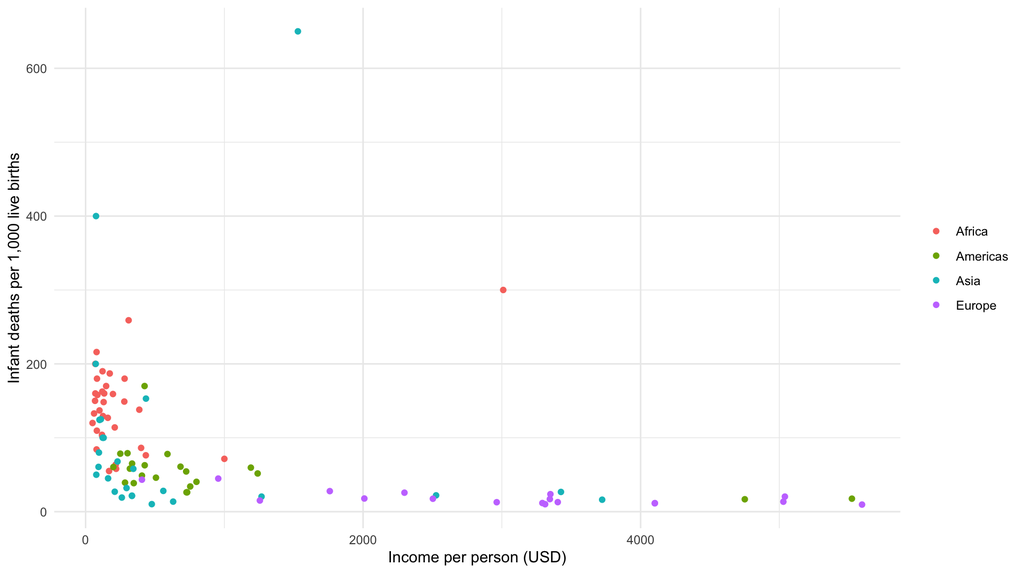

```r
countries_workhorse <- ggplot(infant, aes(x = income_usd_per_capita, y = infant_mortality_per_1000,
                                          color = region)) +
  geom_point() +
  labs(x = "Income per person (USD)", y = "Infant deaths per 1,000 live births", color = NULL)

save_figure(countries_workhorse, "countries-workhorse")
```

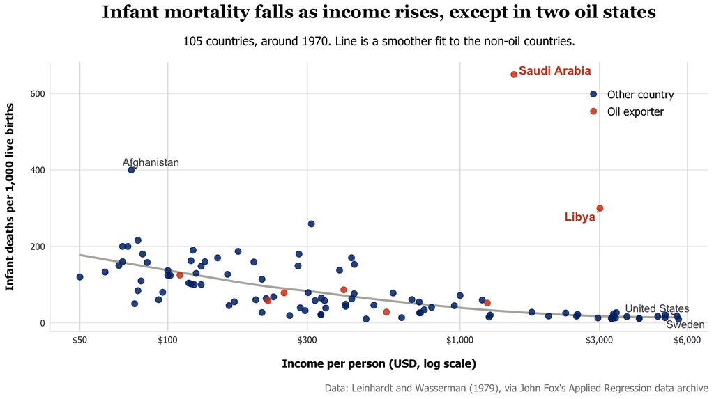

```r
oil_labels <- infant |>
  filter(country %in% c("Saudi Arabia", "Libya"))

other_labels <- infant |>
  filter(country %in% c("Afghanistan", "United States", "Sweden"))

countries_show_pony <- ggplot(infant, aes(x = income_usd_per_capita, y = infant_mortality_per_1000)) +
  geom_smooth(data = filter(infant, !oil_exporter), method = "loess", se = FALSE,
              color = jhu_colors$Gray2, linewidth = 1) +
  geom_point(aes(color = oil_exporter), size = 2.6, alpha = 0.85) +
  ggrepel::geom_text_repel(data = oil_labels, aes(label = country), color = jhu_colors$Red,
                           fontface = "bold", size = 4.2, seed = 1, min.segment.length = 0) +
  ggrepel::geom_text_repel(data = other_labels, aes(label = country), color = jhu_colors$Gray4,
                           size = 3.8, seed = 1, min.segment.length = 0) +
  scale_color_manual(values = c(`TRUE` = jhu_colors$Red, `FALSE` = jhu_colors$HopkinsBlue),
                     labels = c(`TRUE` = "Oil exporter", `FALSE` = "Other country"),
                     name = NULL) +
  scale_x_log10(breaks = c(50, 100, 300, 1000, 3000, 6000),
                labels = scales::label_dollar(accuracy = 1)) +
  labs(
    title = "Infant mortality falls as income rises, except in two oil states",
    subtitle = "105 countries, around 1970. Line is a smoother fit to the non-oil countries.",
    x = "Income per person (USD, log scale)", y = "Infant deaths per 1,000 live births",
    caption = "Data: Leinhardt and Wasserman (1979), via John Fox's Applied Regression data archive"
  ) +
  theme_jhu() +
  theme(legend.position = c(0.88, 0.85), legend.text = element_text(size = 11))

save_figure(countries_show_pony, "countries-show-pony")
```

## Flu vaccination over time

CDC FluVaxView coverage for the United States, measured in May of each season.

```r
age_levels <- c("6 Months - 4 Years", "5-12 Years", "13-17 Years",
                "18-49 Years", "50-64 Years", ">=65 Years")
age_labels <- c("6 months-4 years", "5-12 years", "13-17 years",
                "18-49 years", "50-64 years", "65 and older")

flu_us <- flu |>
  filter(geography == "United States", month == 5, !is.na(estimate)) |>
  mutate(age_group = factor(age_group, levels = age_levels, labels = age_labels))
```

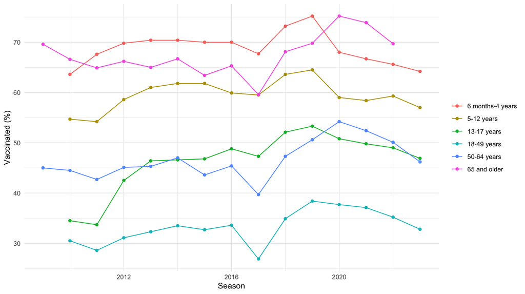

```r
flu_workhorse <- ggplot(flu_us, aes(x = season_start_year, y = estimate, color = age_group)) +
  geom_line() +
  geom_point() +
  labs(x = "Season", y = "Vaccinated (%)", color = NULL)

save_figure(flu_workhorse, "flu-workhorse")
```

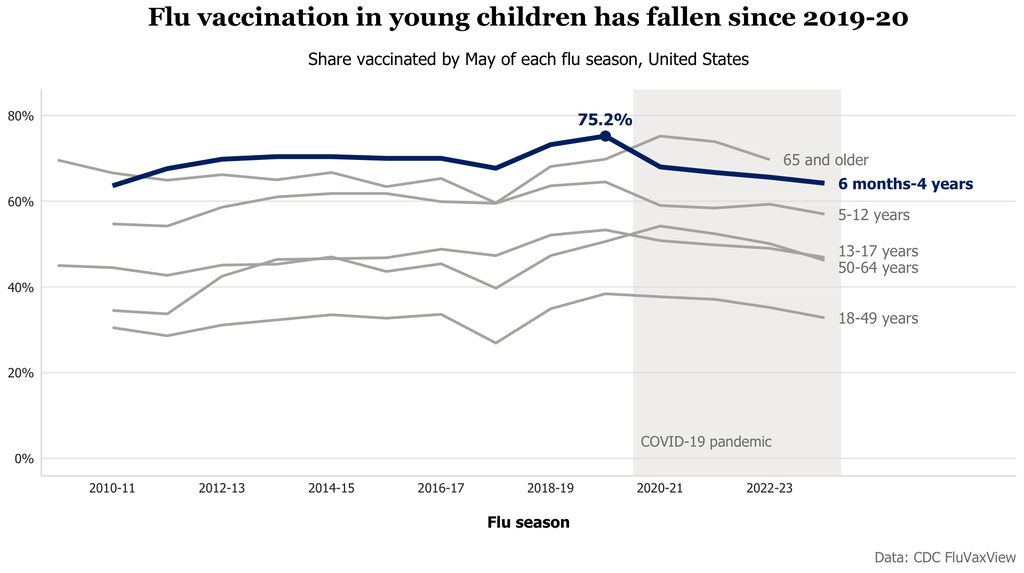

```r
focus <- "6 months-4 years"

flu_ends <- flu_us |>
  group_by(age_group) |>
  filter(season_start_year == max(season_start_year)) |>
  ungroup() |>
  # Nudge two labels that end at nearly the same value
  mutate(label_y = estimate + case_when(
    age_group == "13-17 years" ~ 1.6,
    age_group == "50-64 years" ~ -1.6,
    .default = 0
  ))

peak <- flu_us |>
  filter(age_group == focus) |>
  filter(estimate == max(estimate))

flu_show_pony <- ggplot(flu_us, aes(x = season_start_year, y = estimate, group = age_group)) +
  annotate("rect", xmin = 2019.5, xmax = 2023.3, ymin = -Inf, ymax = Inf,
           fill = jhu_colors$Gray1, alpha = 0.5) +
  annotate("text", x = 2019.65, y = 4, label = "COVID-19 pandemic", hjust = 0,
           color = jhu_colors$Gray3, size = 3.6) +
  geom_line(data = filter(flu_us, age_group != focus), color = jhu_colors$Gray2, linewidth = 0.9) +
  geom_line(data = filter(flu_us, age_group == focus), color = jhu_colors$HopkinsBlue, linewidth = 1.6) +
  geom_point(data = peak, color = jhu_colors$HopkinsBlue, size = 3) +
  annotate("text", x = peak$season_start_year, y = peak$estimate + 4,
           label = paste0(peak$estimate, "%"), color = jhu_colors$HopkinsBlue,
           fontface = "bold", size = 4) +
  geom_text(data = flu_ends, aes(y = label_y, label = age_group, color = age_group == focus),
            fontface = if_else(flu_ends$age_group == focus, "bold", "plain"),
            hjust = 0, nudge_x = 0.25, size = 3.8) +
  scale_color_manual(values = c(`TRUE` = jhu_colors$HopkinsBlue, `FALSE` = jhu_colors$Gray3),
                     guide = "none") +
  scale_x_continuous(breaks = seq(2010, 2022, 2),
                     labels = \(x) paste0(x, "-", substr(x + 1, 3, 4)),
                     expand = expansion(add = c(0.3, 3.2))) +
  scale_y_continuous(limits = c(0, 82), breaks = seq(0, 80, 20),
                     labels = \(x) paste0(x, "%")) +
  labs(
    title = "Flu vaccination in young children has fallen since 2019-20",
    subtitle = "Share vaccinated by May of each flu season, United States",
    x = "Flu season", y = NULL,
    caption = "Data: CDC FluVaxView"
  ) +
  theme_jhu() +
  theme(panel.grid.major.x = element_blank())

save_figure(flu_show_pony, "flu-show-pony")
```